# bf_test

## Ben & Frank Test by Juan Pablo Sada

The goal of this analysis will be to present 2018 Q1 sales. To achive our goal we'll need to:

- Clean the data to get the information we're going to use in our analysis.
- Determine a way to calculate the week days and weekend days with more sales per store.
- Determine the peak hours of shopping.

### Data Cleaning

We'll start by importing the libraries we are using and then cleaning the data to adjust it to our needs.

```python
import pandas as pd
import numpy as np
import matplotlib.pyplot as plt
import matplotlib.dates as mdates
import seaborn as sns
import datetime as dt
```

We will import our csv and display some of the data to check if the file reading was correct. Next we will check the data types to see if theres something that needs to be changed. Finally we are making a quick descriptive anaylisis on our data to se how they behave.

```python
df = pd.read_csv("bf_data.csv")
df
```

|  | Name | Financial Status | Fulfillment Status | Taxes | Total | Discount Amount | Created_at (UTC) | Lineitem quantity | Lineitem price | Cancelled at | Payment Method | Refunded Amount | Location | Source | Lineitem name |
| --- | --- | --- | --- | --- | --- | --- | --- | --- | --- | --- | --- | --- | --- | --- | --- |
| 0 | MX29-1673 | partially_refunded | fulfilled | 468.97 | 3400.0 | 0.0 | 02/01/2018 18:24:00 | 1 | 1799.99 | NaN | External Credit | 150.0 | Tienda A | pos | MARTIN |
| 1 | MX29-1673 | NaN | NaN | NaN | NaN | NaN | 02/01/2018 18:24:00 | 1 | 1600.01 | NaN | NaN | NaN | NaN | NaN | Micas Oftalmicas |
| 2 | MX29-1674 | paid | fulfilled | 344.83 | 2500.0 | 0.0 | 02/01/2018 20:54:00 | 1 | 1799.99 | NaN | External Credit | 0.0 | Tienda A | pos | ALDOUS |
| 3 | MX29-1674 | NaN | NaN | NaN | NaN | NaN | 02/01/2018 20:54:00 | 1 | 700.00 | NaN | NaN | NaN | NaN | NaN | Clipon |
| 4 | MX29-1674 | NaN | NaN | NaN | NaN | NaN | 02/01/2018 20:54:00 | 1 | 0.01 | NaN | NaN | NaN | NaN | NaN | Micas Oftalmicas |
| ... | ... | ... | ... | ... | ... | ... | ... | ... | ... | ... | ... | ... | ... | ... | ... |
| 18778 | MX42-1340 | paid | fulfilled | 248.28 | 1800.0 | 0.0 | 01/04/2018 00:09:00 | 1 | 1799.99 | NaN | External Credit | 0.0 | Tienda A | pos | TRUMAN |
| 18779 | MX42-1341 | NaN | NaN | NaN | NaN | NaN | 01/04/2018 00:50:00 | 1 | 0.01 | NaN | NaN | NaN | NaN | NaN | Micas |
| 18780 | MX42-1341 | partially_refunded | fulfilled | 248.28 | 1800.0 | 0.0 | 01/04/2018 00:50:00 | 1 | 1799.99 | NaN | External Credit | 150.0 | Tienda A | pos | RAMIREZ |
| 18781 | MX42-1342 | NaN | NaN | NaN | NaN | NaN | 01/04/2018 01:11:00 | 1 | 0.01 | NaN | NaN | NaN | NaN | NaN | Micas |
| 18782 | MX42-1342 | paid | fulfilled | 248.28 | 1800.0 | 0.0 | 01/04/2018 01:11:00 | 1 | 1799.99 | NaN | External Credit | 0.0 | Tienda A | pos | TRUMAN |

18783 rows × 15 columns

```python
df.dtypes
```

```
Name                   object
Financial Status       object
Fulfillment Status     object
Taxes                 float64
Total                 float64
Discount Amount       float64
Created_at (UTC)       object
Lineitem quantity       int64
Lineitem price        float64
Cancelled at           object
Payment Method         object
Refunded Amount       float64
Location               object
Source                 object
Lineitem name          object
dtype: object
```

```python
df.describe()
```

|  | Taxes | Total | Discount Amount | Lineitem quantity | Lineitem price | Refunded Amount |
| --- | --- | --- | --- | --- | --- | --- |
| count | 8805.000000 | 8805.000000 | 8805.000000 | 18783.000000 | 18783.000000 | 8805.000000 |
| mean | 265.740282 | 1937.009853 | 77.270315 | 1.022893 | 940.591355 | 32.546848 |
| std | 118.091676 | 859.834905 | 368.731781 | 0.168008 | 872.789180 | 194.615647 |
| min | 0.000000 | 0.000000 | 0.000000 | 1.000000 | 0.000000 | 0.000000 |
| 25% | 248.280000 | 1800.000000 | 0.000000 | 1.000000 | 0.010000 | 0.000000 |
| 50% | 248.280000 | 1800.000000 | 0.000000 | 1.000000 | 1100.010000 | 0.000000 |
| 75% | 248.280000 | 1800.000000 | 0.000000 | 1.000000 | 1799.990000 | 0.000000 |
| max | 2006.900000 | 14550.000000 | 6450.020000 | 7.000000 | 3400.000000 | 4850.000000 |

We can see that the timestamp is in UTC format, we are changing it to CST format, that its Mexicos central time.

```python
df["Created_at (UTC)"] = pd.to_datetime(df["Created_at (UTC)"], format="%d/%m/%Y %H:%M:%S")
df["Created_at (UTC)"] = df["Created_at (UTC)"].dt.tz_localize("UTC")
df["Created_at (UTC)"] = df["Created_at (UTC)"].dt.tz_convert("US/Central")
df.head()
```

|  | Name | Financial Status | Fulfillment Status | Taxes | Total | Discount Amount | Created_at (UTC) | Lineitem quantity | Lineitem price | Cancelled at | Payment Method | Refunded Amount | Location | Source | Lineitem name |
| --- | --- | --- | --- | --- | --- | --- | --- | --- | --- | --- | --- | --- | --- | --- | --- |
| 0 | MX29-1673 | partially_refunded | fulfilled | 468.97 | 3400.0 | 0.0 | 2018-01-02 12:24:00-06:00 | 1 | 1799.99 | NaN | External Credit | 150.0 | Tienda A | pos | MARTIN |
| 1 | MX29-1673 | NaN | NaN | NaN | NaN | NaN | 2018-01-02 12:24:00-06:00 | 1 | 1600.01 | NaN | NaN | NaN | NaN | NaN | Micas Oftalmicas |
| 2 | MX29-1674 | paid | fulfilled | 344.83 | 2500.0 | 0.0 | 2018-01-02 14:54:00-06:00 | 1 | 1799.99 | NaN | External Credit | 0.0 | Tienda A | pos | ALDOUS |
| 3 | MX29-1674 | NaN | NaN | NaN | NaN | NaN | 2018-01-02 14:54:00-06:00 | 1 | 700.00 | NaN | NaN | NaN | NaN | NaN | Clipon |
| 4 | MX29-1674 | NaN | NaN | NaN | NaN | NaN | 2018-01-02 14:54:00-06:00 | 1 | 0.01 | NaN | NaN | NaN | NaN | NaN | Micas Oftalmicas |

We are going to extract from the `Created_at (UTC)` three additional columns:

1. Date - Date when the sale was done.
2. Day of the Week - Day of the week the sale was done. (Monday = 0 and Sunday = 6)
3. Hour - Hour of the Day when the sale was done.

```python
df["Date"] = df["Created_at (UTC)"].dt.date
df["Day of Week"] = df["Created_at (UTC)"].dt.dayofweek
df["Hour"] = df["Created_at (UTC)"].dt.hour
df
```

|  | Name | Financial Status | Fulfillment Status | Taxes | Total | Discount Amount | Created_at (UTC) | Lineitem quantity | Lineitem price | Cancelled at | Payment Method | Refunded Amount | Location | Source | Lineitem name | Date | Day of Week | Hour |
| --- | --- | --- | --- | --- | --- | --- | --- | --- | --- | --- | --- | --- | --- | --- | --- | --- | --- | --- |
| 0 | MX29-1673 | partially_refunded | fulfilled | 468.97 | 3400.0 | 0.0 | 2018-01-02 12:24:00-06:00 | 1 | 1799.99 | NaN | External Credit | 150.0 | Tienda A | pos | MARTIN | 2018-01-02 | 1 | 12 |
| 1 | MX29-1673 | NaN | NaN | NaN | NaN | NaN | 2018-01-02 12:24:00-06:00 | 1 | 1600.01 | NaN | NaN | NaN | NaN | NaN | Micas Oftalmicas | 2018-01-02 | 1 | 12 |
| 2 | MX29-1674 | paid | fulfilled | 344.83 | 2500.0 | 0.0 | 2018-01-02 14:54:00-06:00 | 1 | 1799.99 | NaN | External Credit | 0.0 | Tienda A | pos | ALDOUS | 2018-01-02 | 1 | 14 |
| 3 | MX29-1674 | NaN | NaN | NaN | NaN | NaN | 2018-01-02 14:54:00-06:00 | 1 | 700.00 | NaN | NaN | NaN | NaN | NaN | Clipon | 2018-01-02 | 1 | 14 |
| 4 | MX29-1674 | NaN | NaN | NaN | NaN | NaN | 2018-01-02 14:54:00-06:00 | 1 | 0.01 | NaN | NaN | NaN | NaN | NaN | Micas Oftalmicas | 2018-01-02 | 1 | 14 |
| ... | ... | ... | ... | ... | ... | ... | ... | ... | ... | ... | ... | ... | ... | ... | ... | ... | ... | ... |
| 18778 | MX42-1340 | paid | fulfilled | 248.28 | 1800.0 | 0.0 | 2018-03-31 19:09:00-05:00 | 1 | 1799.99 | NaN | External Credit | 0.0 | Tienda A | pos | TRUMAN | 2018-03-31 | 5 | 19 |
| 18779 | MX42-1341 | NaN | NaN | NaN | NaN | NaN | 2018-03-31 19:50:00-05:00 | 1 | 0.01 | NaN | NaN | NaN | NaN | NaN | Micas | 2018-03-31 | 5 | 19 |
| 18780 | MX42-1341 | partially_refunded | fulfilled | 248.28 | 1800.0 | 0.0 | 2018-03-31 19:50:00-05:00 | 1 | 1799.99 | NaN | External Credit | 150.0 | Tienda A | pos | RAMIREZ | 2018-03-31 | 5 | 19 |
| 18781 | MX42-1342 | NaN | NaN | NaN | NaN | NaN | 2018-03-31 20:11:00-05:00 | 1 | 0.01 | NaN | NaN | NaN | NaN | NaN | Micas | 2018-03-31 | 5 | 20 |
| 18782 | MX42-1342 | paid | fulfilled | 248.28 | 1800.0 | 0.0 | 2018-03-31 20:11:00-05:00 | 1 | 1799.99 | NaN | External Credit | 0.0 | Tienda A | pos | TRUMAN | 2018-03-31 | 5 | 20 |

18783 rows × 18 columns

We are going to delete all the rows that doesn't have a value in `Location` column.

```python
df = df[df["Location"].notnull()].reset_index(drop=True)
df
```

|  | Name | Financial Status | Fulfillment Status | Taxes | Total | Discount Amount | Created_at (UTC) | Lineitem quantity | Lineitem price | Cancelled at | Payment Method | Refunded Amount | Location | Source | Lineitem name | Date | Day of Week | Hour |
| --- | --- | --- | --- | --- | --- | --- | --- | --- | --- | --- | --- | --- | --- | --- | --- | --- | --- | --- |
| 0 | MX29-1673 | partially_refunded | fulfilled | 468.97 | 3400.0 | 0.0 | 2018-01-02 12:24:00-06:00 | 1 | 1799.99 | NaN | External Credit | 150.0 | Tienda A | pos | MARTIN | 2018-01-02 | 1 | 12 |
| 1 | MX29-1674 | paid | fulfilled | 344.83 | 2500.0 | 0.0 | 2018-01-02 14:54:00-06:00 | 1 | 1799.99 | NaN | External Credit | 0.0 | Tienda A | pos | ALDOUS | 2018-01-02 | 1 | 14 |
| 2 | MX29-1675 | paid | fulfilled | 248.28 | 1800.0 | 0.0 | 2018-01-02 15:15:00-06:00 | 1 | 1799.99 | NaN | External Credit | 0.0 | Tienda A | pos | DARIA JR | 2018-01-02 | 1 | 15 |
| 3 | MX29-1676 | paid | fulfilled | 248.28 | 1800.0 | 0.0 | 2018-01-02 16:45:00-06:00 | 1 | 1799.99 | NaN | External Credit | 0.0 | Tienda A | pos | JANIS | 2018-01-02 | 1 | 16 |
| 4 | MX29-1677 | paid | fulfilled | 227.58 | 1650.0 | 150.0 | 2018-01-02 17:16:00-06:00 | 1 | 1799.99 | NaN | External Credit | 0.0 | Tienda A | pos | ESQUIVEL | 2018-01-02 | 1 | 17 |
| ... | ... | ... | ... | ... | ... | ... | ... | ... | ... | ... | ... | ... | ... | ... | ... | ... | ... | ... |
| 8799 | MX42-1338 | paid | fulfilled | 317.24 | 2300.0 | 0.0 | 2018-03-31 16:28:00-05:00 | 1 | 1799.99 | NaN | Cash | 0.0 | Tienda A | pos | ALDOUS | 2018-03-31 | 5 | 16 |
| 8800 | MX42-1339 | partially_refunded | fulfilled | 248.28 | 1800.0 | 0.0 | 2018-03-31 19:06:00-05:00 | 1 | 0.01 | NaN | External Credit | 300.0 | Tienda A | pos | Micas | 2018-03-31 | 5 | 19 |
| 8801 | MX42-1340 | paid | fulfilled | 248.28 | 1800.0 | 0.0 | 2018-03-31 19:09:00-05:00 | 1 | 1799.99 | NaN | External Credit | 0.0 | Tienda A | pos | TRUMAN | 2018-03-31 | 5 | 19 |
| 8802 | MX42-1341 | partially_refunded | fulfilled | 248.28 | 1800.0 | 0.0 | 2018-03-31 19:50:00-05:00 | 1 | 1799.99 | NaN | External Credit | 150.0 | Tienda A | pos | RAMIREZ | 2018-03-31 | 5 | 19 |
| 8803 | MX42-1342 | paid | fulfilled | 248.28 | 1800.0 | 0.0 | 2018-03-31 20:11:00-05:00 | 1 | 1799.99 | NaN | External Credit | 0.0 | Tienda A | pos | TRUMAN | 2018-03-31 | 5 | 20 |

8804 rows × 18 columns

Now our data is clean, and we are reday to star our analysis.

### Data Analysis

In our analysis we will show the next metrics:

- Sales
- Most popular day of the week
- Average Ticket
- Peak Hour

#### Sales

```
The following chart show the first quarter sales in mexican pesos. The peaks shown in the chart are equivalent to
weekend days where more sales are made.
Total Sales = $17054671.759999998
```

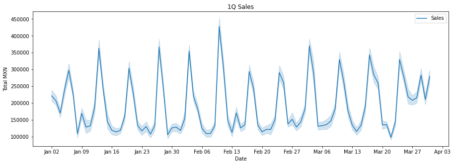

```python
fig, ax = plt.subplots(figsize=(15,5))
sns.lineplot(x=df["Date"], y=df["Total"], label="Sales", data=df, estimator="sum")
ax.xaxis.set_major_locator(mdates.WeekdayLocator())
ax.xaxis.set_major_formatter(mdates.DateFormatter('%b %d'))
plt.title("1Q Sales")
plt.xlabel("Date")
plt.ylabel("Total MXN")

total_sales = df["Total"].sum()

print("""
The following chart show the first quarter sales in mexican pesos. The peaks shown in the chart are equivalent to\nweekend days where more sales are made.""")
print(f"Total Sales = ${total_sales}")
```

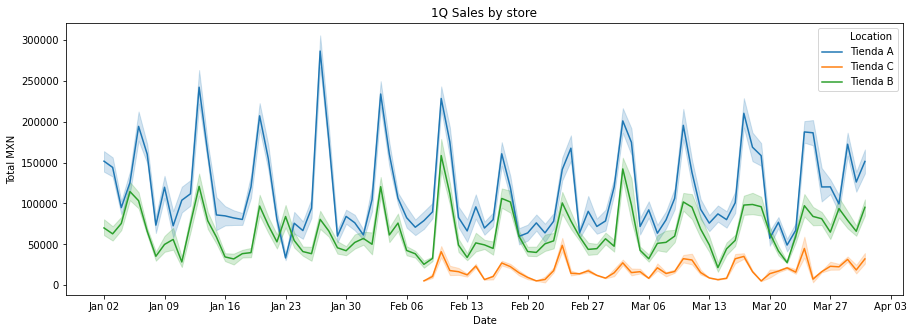

```python
fig, ax = plt.subplots(figsize=(15,5))
sns.lineplot(x=df["Date"], y=df["Total"], data=df, estimator="sum", hue=df["Location"])
ax.xaxis.set_major_locator(mdates.WeekdayLocator())
ax.xaxis.set_major_formatter(mdates.DateFormatter('%b %d'))
plt.title("1Q Sales by store")
plt.xlabel("Date")
plt.ylabel("Total MXN")
```

#### Most popular day of the week

```
We can see that 56.474329850068145% of the sales are done during the weekend, being Saturday the most popular day.
```

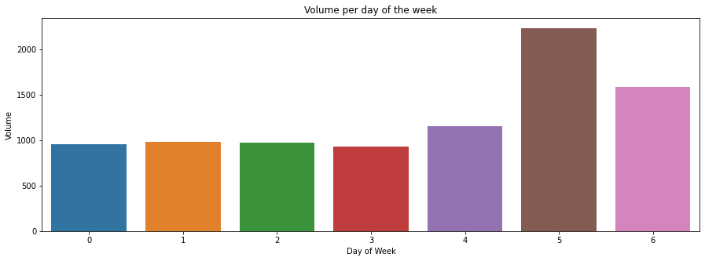

```python
fig, ax = plt.subplots(figsize=(15,5))
sns.countplot(x=df["Day of Week"])
plt.ylabel("Volume")
plt.title("Volume per day of the week")
weekday_distro = df["Day of Week"].value_counts(normalize=True)*100

print(f"We can see that {weekday_distro[4]+weekday_distro[5]+weekday_distro[6]}% of the sales are done during the weekend, being Saturday the most popular day.")
```

```
We can see that 56.474329850068145% of the sales are done during the weekend, being Saturday the most popular day. Tuesday is the day with more sales in week days
```

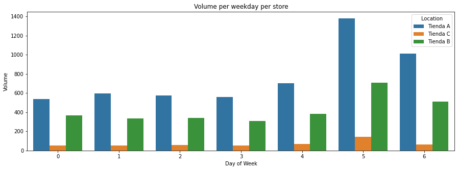

```python
fig, ax = plt.subplots(figsize=(15,5))
sns.countplot(x=df["Day of Week"], hue=df["Location"])
plt.ylabel("Volume")
plt.title("Volume per weekday per store")
weekday_distro = df["Day of Week"].value_counts(normalize=True)*100

print(f"We can see that {weekday_distro[4]+weekday_distro[5]+weekday_distro[6]}% of the sales are done during the weekend, being Saturday the most popular day. Tuesday is the day with more sales in week days")
```

#### Average Ticket

```
This chart shows the average ticket by date and the horizontal line tells us the general average ticket.
Average ticket = $1937.15035892776 mexican pesos.
```

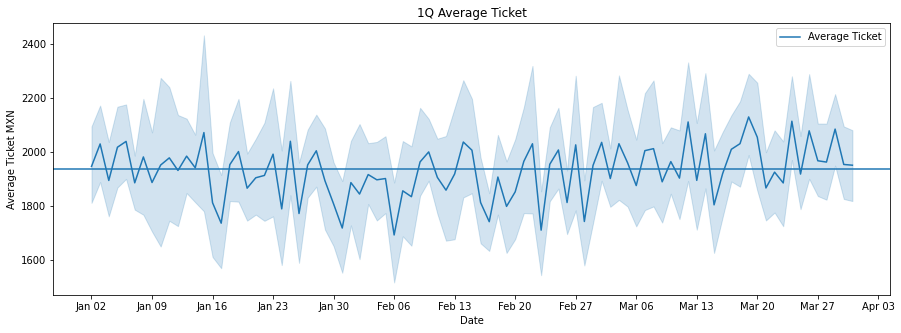

```python
average_ticket = df["Total"].mean()
fig, ax = plt.subplots(figsize=(15,5))
sns.lineplot(x=df["Date"], y=df["Total"], label="Average Ticket", data=df)
ax.xaxis.set_major_locator(mdates.WeekdayLocator())
ax.xaxis.set_major_formatter(mdates.DateFormatter('%b %d'))
plt.title("1Q Average Ticket")
plt.xlabel("Date")
plt.ylabel("Average Ticket MXN")
plt.axhline(average_ticket)
print(f"This chart shows the average ticket by date and the horizontal line tells us the general average ticket.")
print(f"Average ticket = ${average_ticket} mexican pesos.")
```

#### Peak Hour

```
To get the peak hours we computed a KDE distribution where the highest peak is the hour with the higher amount of sales. The general peak hour is at 18:00
--------------------
General peak hours
--------------------
18    1203
17    1185
14    1166
13    1123
16    1051
19    1003
15     996
12     635
20     400
21      34
11       8
Name: Hour, dtype: int64
```

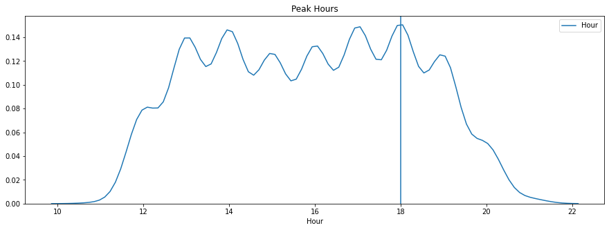

```python
fig, ax = plt.subplots(figsize=(15,5))
sns.kdeplot(df["Hour"])
plt.title("Peak Hours")
plt.xlabel("Hour")
plt.axvline(18)
print(f"To get the peak hours we computed a KDE distribution where the highest peak is the hour with the higher amount of sales. The general peak hour is at 18:00")
print("--------------------")
print(f"General peak hours")
print("--------------------")
print(df["Hour"].value_counts())
```

```python
peak_hours = df["Hour"].value_counts()
```

```
--------------------
Store A peak hours
--------------------
14    741
18    706
17    705
13    681
15    627
16    619
19    616
12    402
20    238
21     24
Name: Hour, dtype: int64
None

--------------------
Store B peak hours
--------------------
18    438
17    421
13    375
16    370
14    360
19    343
15    302
12    199
20    136
21      9
11      1
Name: Hour, dtype: int64
None

--------------------
Store C peak hours
--------------------
15    67
13    67
14    65
16    62
18    59
17    59
19    44
12    34
20    26
11     7
21     1
Name: Hour, dtype: int64
None
```

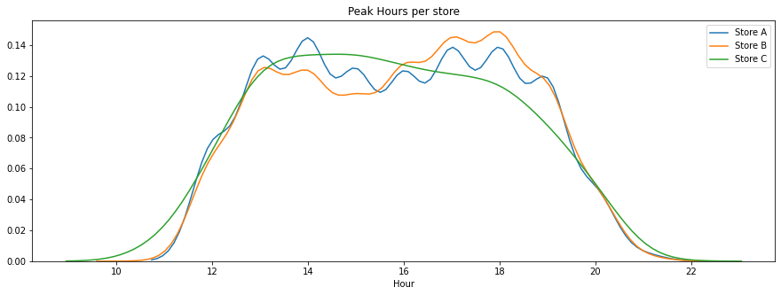

```python
fig, ax = plt.subplots(figsize=(15,5))
sns.kdeplot(df[df["Location"] == "Tienda A"]["Hour"], label="Store A")
sns.kdeplot(df[df["Location"] == "Tienda B"]["Hour"], label="Store B")
sns.kdeplot(df[df["Location"] == "Tienda C"]["Hour"], label="Store C")
plt.title("Peak Hours per store")
plt.xlabel("Hour")
print("--------------------")
print("Store A peak hours")
print("--------------------")
print(print(df[df["Location"] == "Tienda A"]["Hour"].value_counts()))
print("")
print("--------------------")
print("Store B peak hours")
print("--------------------")
print(print(df[df["Location"] == "Tienda B"]["Hour"].value_counts()))
print("")
print("--------------------")
print("Store C peak hours")
print("--------------------")
print(print(df[df["Location"] == "Tienda C"]["Hour"].value_counts()))
```